# DS AND ML WITH PYTHON slides

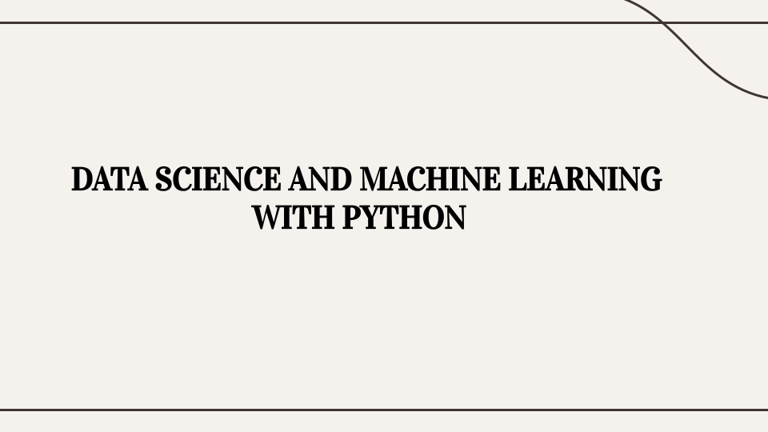

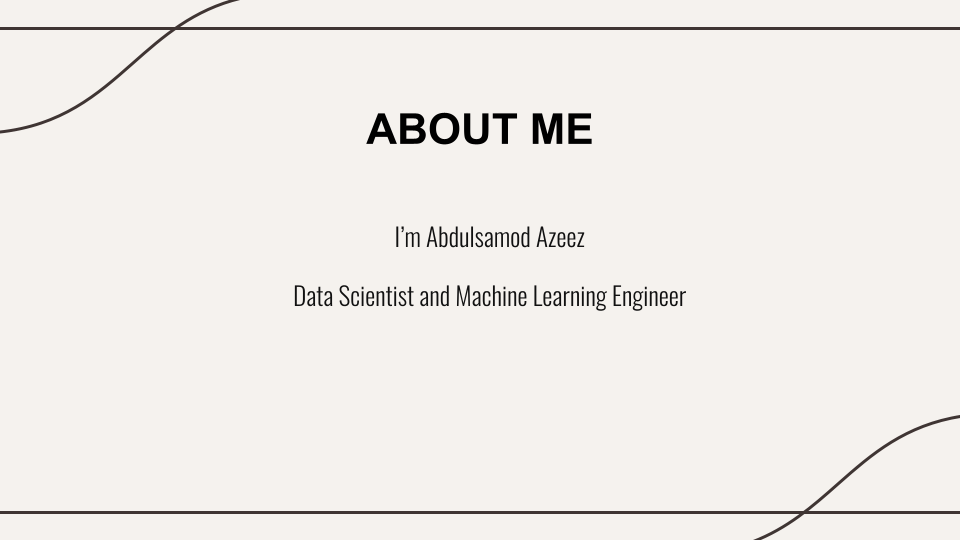

## Contents

- Introduction to Artificial Intelligence (AI)
- Data Science and Machine Learning Fundamentals
- Introduction to Python Programming Language
- Predicting Penguins Species

## MODULE ONE: INTRODUCTION TO ARTIFICIAL INTELLIGENCE (AI)

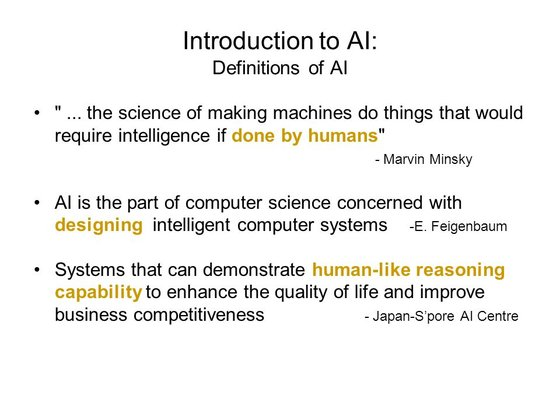

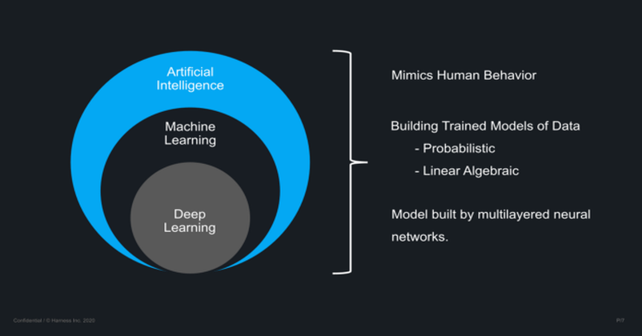

[figure not shown]

### Applications of AI

- Healthcare
- Education
- Autonomous Vehicles
- Business
- Travel Industry

## MODULE TWO: INTRODUCTION TO DATA SCIENCE

DS is a "concept to unify statistics, data analysis, machine learning, domain knowledge and other related methods" in order to understand, gain insight or derive pattern from data.

**The goal of every data science project is to obtain meaningful business information from data in order to make better decisions. It is the role of data scientists to define the project's objectives. This necessitates business knowledge and experience.**

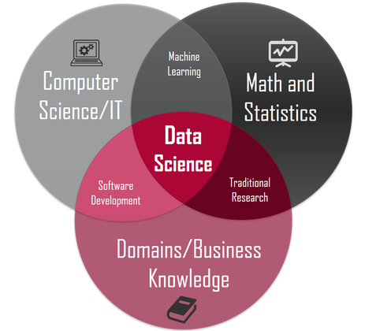

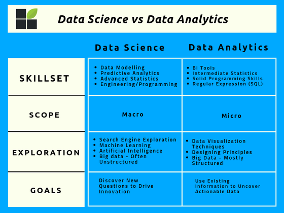

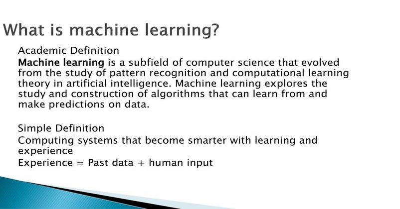

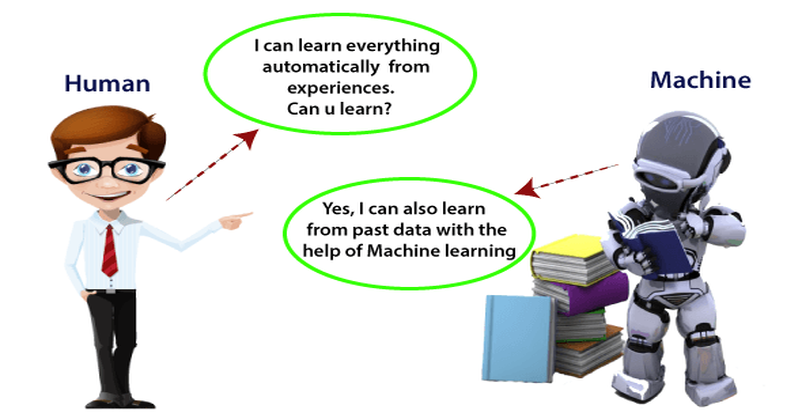

## TYPES OF MACHINE LEARNING

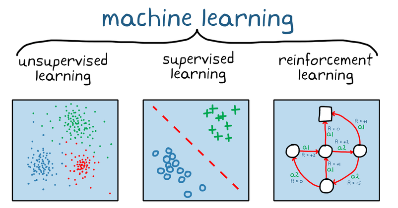

1. **Supervised Machine Learning**

Supervised machine learning is based on supervision. It means that in the supervised learning technique, we train the machines using the "labelled" dataset, and the machine predicts the output based on the training. The tagged data in this case indicates that some of the inputs have already been mapped to the output. To put it another way, we first train the machine with the input and associated output, and then we ask the machine to predict the outcome using the test dataset.

**Categories of Supervised Machine Learning**

Supervised machine learning can be classified into two types of problems, which are given below:

- Classification
- Regression

A.Classification

Classification algorithms are used to handle classification issues using categorical output variables, such as "Yes" or "No," Male or Female, Red or Blue, and so on. The categories in the dataset are predicted by the categorization algorithms. Spam detection, email filtering, and other real-world examples of classification algorithms

Some popular classification algorithms are given below:

- Random Forest Algorithm
- Decision Tree Algorithm
- Logistic Regression Algorithm
- Support Vector Machine Algorithm

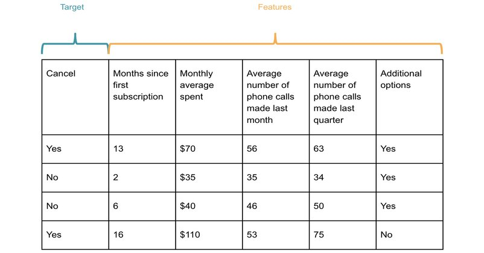

b. Regression

Regression algorithms are used to solve regression problems in which there is a linear relationship between input and output variables. These are used to predict continuous output variables, such as market trends, weather prediction, etc.

Some popular Regression algorithms are given below:

- Simple Linear Regression Algorithm
- Multivariate Regression Algorithm
- Decision Tree Algorithm
- Lasso Regression
- Random Forest Algorithm

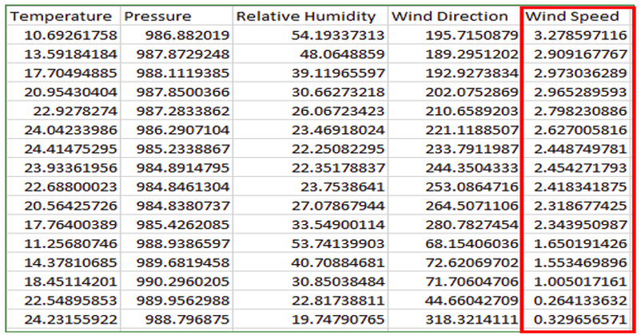

2.Unsupervised Machine Learning

Unsupervised learning is different from the Supervised learning technique; as its name suggests, there is no need for supervision. It means, in unsupervised machine learning, the machine is trained using the unlabeled dataset, and the machine predicts the output without any supervision.

The main aim of the unsupervised learning algorithm is to group or categories the unsorted dataset according to the similarities, patterns, and differences. Machines are instructed to find the hidden patterns from the input dataset.

One of the example of unsupervised machine learning is:

- Clustering The clustering technique is used when we want to find the inherent groups from the data. It is a way to group the objects into a cluster such that the objects with the most similarities remain in one group and have fewer or no similarities with the objects of other groups. An example of the clustering algorithm is grouping the customers by their purchasing behaviour.

Some of the popular clustering algorithms are given below:

3.Reinforcement Learning

Reinforcement learning works on a feedback-based process, in which an AI agent (A software component) automatically explore its surrounding by hitting & trail, taking action, learning from experiences, and improving its performance. Agent gets rewarded for each good action and get punished for each bad action; hence the goal of reinforcement learning agent is to maximize the rewards.

In reinforcement learning, there is no labelled data like supervised learning, and agents learn from their experiences only.

### Quick Summary on the Types of Machine Learning, their Categories and Alogorithm Used

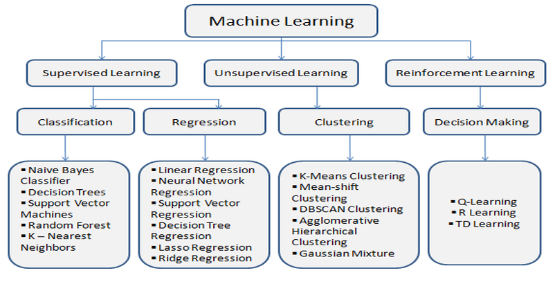

## Applications for Data Science

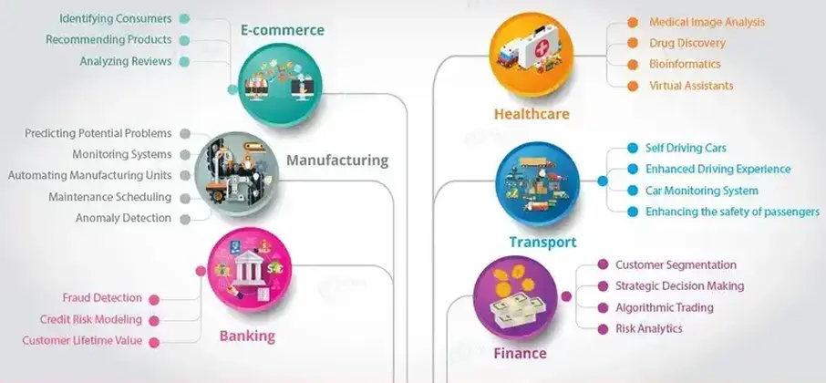

## Steps in Solving Data Science Problems

Running a data science project usually involves multiple steps, including the following:

1. Defining the business problem to be solved
2. Collecting or extracting existing data
3. Analyzing, visualizing, and preparing data
4. Training a model to spot patterns in data and make predictions
5. Assessing a model's performance and making improvements
6. Communicating and presenting findings and gained insights
7. Deploying and maintaining a model

# MODULE Three: INTRODUCTION TO PYTHON PROGRAMMING LANGUAGE

Python is a popular programming language. It was created by Guido van Rossum, and released in 1991.

It is used for:

- web development (server-side),
- software development,
- mathematics,
- system scripting.

**What can Python do?**

- Python can be used on a server to create web applications.
- Python can be used alongside software to create workflows.
- Python can connect to database systems. It can also read and modify files.
- Python can be used to handle big data and perform complex mathematics.
- Python can be used for rapid prototyping, or for production-ready software development.

**Why Python?**

- Python works on different platforms (Windows, Mac, Linux, Raspberry Pi, etc).
- Python has a simple syntax similar to the English language.
- Python has syntax that allows developers to write programs with fewer lines than some other programming languages.
- Python runs on an interpreter system, meaning that code can be executed as soon as it is written. This means that prototyping can be very quick.
- Python can be treated in a procedural way, an object-oriented way or a functional way.

**Good to know**

The most recent major version of Python is Python 3, which we shall be using in this workshop. However, Python 2, although not being updated with anything other than security updates, is still quite popular.

```python
# The Print function is use to display the output

print("Hello World")
```

```
Hello World
```

```python
# Creating a variable

name_of_school = "Thomas Adewumi University"
print(name_of_school)

level= 200
print(level)
```

```
Thomas Adewumi University
200
```

## Python Data Types

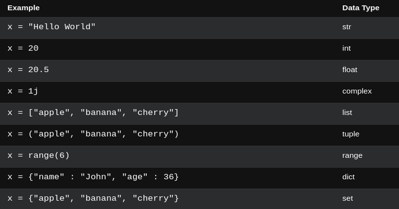

## Python Loops

Python has two primitive loop commands:

- while loops
- for loops

```python
#The while loop
#With the while loop we can execute a set of statements as long as a condition is true.

i = 1
while i < 5:
    print(i)
    i += 1
```

```
1
2
3
4
```

```python
#The break statment
i = 1
while i < 6:
    print(i)
    if i == 3:
        break
    i += 1
```

```
1
2
3
```

```python
#A for loop is used for iterating over a sequence (that is either a list, a tuple, a dictionary, a set, or a string).

fruits = ["apple", "banana", "cherry"]
for x in fruits:
    print(x)
```

```
apple
banana
cherry
```

```python
fruits = ["apple", "banana", "cherry"]
for x in fruits:
    print(x)
    if x == "banana":
        break
```

```
apple
banana
```

```python
for x in "banana":
    print(x)
```

```
b
a
n
a
n
a
```

## Function

A function is a block of code which only runs when it is called.

You can pass data, known as parameters, into a function.

A function can return data as a result.

**Creating a Function**

In Python a function is defined using the def keyword:

```python
def my_function():
    print("Hello World")
```

```python
# Calling a function

def my_function():
    print("Hello World")

my_function()
```

```
Hello World
```

```python
def my_function(fname):
    print(fname + " Adewumi")

my_function("Thomas")
```

```
Thomas Adewumi
```

# MODULE Four: PREDICTING PENGUINS SPECIES

**AIM**: Predicting penguine species

The data for this activity comes from a study of three different species of Antartic penguin: Adelie, Chinstrap and Gentoo.

In this notebook you will explore which features can be used to predict the species of a penguin.

You will build a model to predict whether a particular penguin is either a Gentoo,Adelie or Chinstrap penguin.

The dataset consists of 7 columns.

- **species**: penguin species (Chinstrap, Adélie, or Gentoo)
- **culmen_length_mm**: culmen length (mm)
- **culmen_depth_mm**: culmen depth (mm)
- **flipper_length_mm**: flipper length (mm)
- **body_mass_g**: body mass (g)
- **island**: island name (Dream, Torgersen, or Biscoe) in the Palmer Archipelago (Antarctica)
- **sex**: penguin sex

[figure not shown]

**DATASET**

Data were collected and made available by Dr. Kristen Gorman and the Palmer Station, Antarctica LTER, a member of the Long Term Ecological Research Network.

penguins_size.csv: Simplified data from original penguin data sets. Contains variables:

- species: penguin species (Chinstrap, Adélie, or Gentoo)
- culmen_length_mm: culmen length (mm)
- culmen_depth_mm: culmen depth (mm)
- flipper_length_mm: flipper length (mm)
- body_mass_g: body mass (g)
- island: island name (Dream, Torgersen, or Biscoe) in the Palmer Archipelago (Antarctica)
- sex: penguin sex

```python
import numpy as np
import pandas as pd
from sklearn.preprocessing import LabelEncoder
from sklearn.preprocessing import StandardScaler
import os

# Visualisation libraries
import matplotlib.pyplot as plt
%matplotlib inline
import seaborn as sns
```

# Importing the dataset

```python
df = pd.read_csv('penguins_size.csv')
df.head()
```

|  | species | island | culmen_length_mm | culmen_depth_mm | flipper_length_mm | body_mass_g | sex |
| --- | --- | --- | --- | --- | --- | --- | --- |
| 0 | Adelie | Torgersen | 39.1 | 18.7 | 181.0 | 3750.0 | MALE |
| 1 | Adelie | Torgersen | 39.5 | 17.4 | 186.0 | 3800.0 | FEMALE |
| 2 | Adelie | Torgersen | 40.3 | 18.0 | 195.0 | 3250.0 | FEMALE |
| 3 | Adelie | Torgersen | NaN | NaN | NaN | NaN | NaN |
| 4 | Adelie | Torgersen | 36.7 | 19.3 | 193.0 | 3450.0 | FEMALE |